# Introduction to R: Vectors, matrices and arrays

A. Kaliontzopoulou, A. Jesús Muñoz-Pajares, P. Tarroso

4-8 November 2019

## **Content Description**

This lecture focuses on three of the main R data types: vectors, matrices and arrays. These are R data objects with specific properties and with a direct link to algebraic operations. In most cases they will be numerical, but they can also be of character or logical class. All of them are restricted to a single class of elements, i.e. being exclusively numeric or coersed to character if different classes are introduced.

## **VECTORS**

A vector is a simple array (one dimmension) of numbers or characters, such as the measurements of a single variable A vector is a sequence of data elements of the same basic class A vector is defined by its mode and length

We already saw yesterday how the combine function can be used to create vectors.

```r
# a numeric vector
x <- c(20, 50, 100)
x
```

```
## [1]  20  50 100
```

```r
# a logical vector
x <- c(TRUE, FALSE, TRUE, FALSE, FALSE)
x
```

```
## [1]  TRUE FALSE  TRUE FALSE FALSE
```

```r
# a vector of characters
x <- c("GG","TT","GA","AT","CC")
x
```

```
## [1] "GG" "TT" "GA" "AT" "CC"
```

Note that a vector cannot mix different types of elements. In doing so, numbers are coerced to characters to maintain the same type of elements.

```r
x <- c(2,3,5)
y <- c("a", "b", "c")
z <- c(x,y)
z
```

```
## [1] "2" "3" "5" "a" "b" "c"
```

```r
class(x)
```

```
## [1] "numeric"
```

```r
class(y)
```

```
## [1] "character"
```

```r
class(z)
```

```
## [1] "character"
```

A vector can be defined by its mode() and its lenght()

```r
mode(x)
length(x)
```

[output not shown]

## **CREATING VECTORS**

There are several functions in R for creating specific types of vectors, i.e. by drawing random numbers from a distribution, by repeating elements, or through sequences.

# **Sequences**

```r
x <- 1:20
x
```

```
##  [1]  1  2  3  4  5  6  7  8  9 10 11 12 13 14 15 16 17 18 19 20
```

```r
1:20-1
```

```
##  [1]  0  1  2  3  4  5  6  7  8  9 10 11 12 13 14 15 16 17 18 19
```

```r
1:(20-1)
```

```
##  [1]  1  2  3  4  5  6  7  8  9 10 11 12 13 14 15 16 17 18 19
```

```r
?seq
seq(from=1, to=20, by=1)
```

```
##  [1]  1  2  3  4  5  6  7  8  9 10 11 12 13 14 15 16 17 18 19 20
```

```r
seq(0, 10, 0.1)
```

```
##   [1]  0.0  0.1  0.2  0.3  0.4  0.5  0.6  0.7  0.8  0.9  1.0  1.1  1.2  1.3
##  [15]  1.4  1.5  1.6  1.7  1.8  1.9  2.0  2.1  2.2  2.3  2.4  2.5  2.6  2.7
##  [29]  2.8  2.9  3.0  3.1  3.2  3.3  3.4  3.5  3.6  3.7  3.8  3.9  4.0  4.1
##  [43]  4.2  4.3  4.4  4.5  4.6  4.7  4.8  4.9  5.0  5.1  5.2  5.3  5.4  5.5
##  [57]  5.6  5.7  5.8  5.9  6.0  6.1  6.2  6.3  6.4  6.5  6.6  6.7  6.8  6.9
##  [71]  7.0  7.1  7.2  7.3  7.4  7.5  7.6  7.7  7.8  7.9  8.0  8.1  8.2  8.3
##  [85]  8.4  8.5  8.6  8.7  8.8  8.9  9.0  9.1  9.2  9.3  9.4  9.5  9.6  9.7
##  [99]  9.8  9.9 10.0
```

```r
seq(length=9, from=1, to=5)
```

```
## [1] 1.0 1.5 2.0 2.5 3.0 3.5 4.0 4.5 5.0
```

```r
seq(from=1, to=5, length=9)
```

```
## [1] 1.0 1.5 2.0 2.5 3.0 3.5 4.0 4.5 5.0
```

```r
?sequence
sequence(5)
```

```
## [1] 1 2 3 4 5
```

```r
sequence(3:5)
```

```
##  [1] 1 2 3 1 2 3 4 1 2 3 4 5
```

# **Repeat**

```r
?rep
rep(1, 50)
```

```
##  [1] 1 1 1 1 1 1 1 1 1 1 1 1 1 1 1 1 1 1 1 1 1 1 1 1 1 1 1 1 1 1 1 1 1 1 1
## [36] 1 1 1 1 1 1 1 1 1 1 1 1 1 1 1
```

```r
rep(1:4, 2)
```

```
## [1] 1 2 3 4 1 2 3 4
```

```r
rep(1:4, each=2)
```

```
## [1] 1 1 2 2 3 3 4 4
```

```r
rep(1:4, c(2,4, 5, 3))
```

```
##  [1] 1 1 2 2 2 2 3 3 3 3 3 4 4 4
```

```r
rep(1:4, each=2, times=10)
```

```
##  [1] 1 1 2 2 3 3 4 4 1 1 2 2 3 3 4 4 1 1 2 2 3 3 4 4 1 1 2 2 3 3 4 4 1 1 2
## [36] 2 3 3 4 4 1 1 2 2 3 3 4 4 1 1 2 2 3 3 4 4 1 1 2 2 3 3 4 4 1 1 2 2 3 3
## [71] 4 4 1 1 2 2 3 3 4 4
```

This also works with characters, and using other vectors

```r
y <- c("a", "b", "c")
r <- rep(y, 3)
```

# **Random numbers**

We can draw random numbers from an already existing vector. This is very useful for e.g. data suffling during permutation procedures.

```r
?sample
x <- sample(1:5, 5, replace=F)
x
```

```
## [1] 1 2 5 3 4
```

```r
#y <- sample(1:5, 6, replace=F) does not work
y <- sample(1:5, 6, replace=T)
y
```

```
## [1] 5 3 5 5 2 5
```

```r
duplicated(y)
```

```
## [1] FALSE FALSE  TRUE  TRUE FALSE  TRUE
```

```r
sample(r, 20, replace = T)
```

```
##  [1] "c" "b" "a" "a" "c" "b" "a" "a" "a" "a" "c" "b" "a" "a" "b" "b" "b"
## [18] "a" "c" "c"
```

We can also draw random numbers from specific statistical distributions.

```r
?runif
x <- runif(10)
x
```

```
##  [1] 0.5695168 0.6711377 0.3430763 0.8787680 0.1931758 0.1370561 0.3933820
##  [8] 0.4430345 0.9999950 0.5407066
```

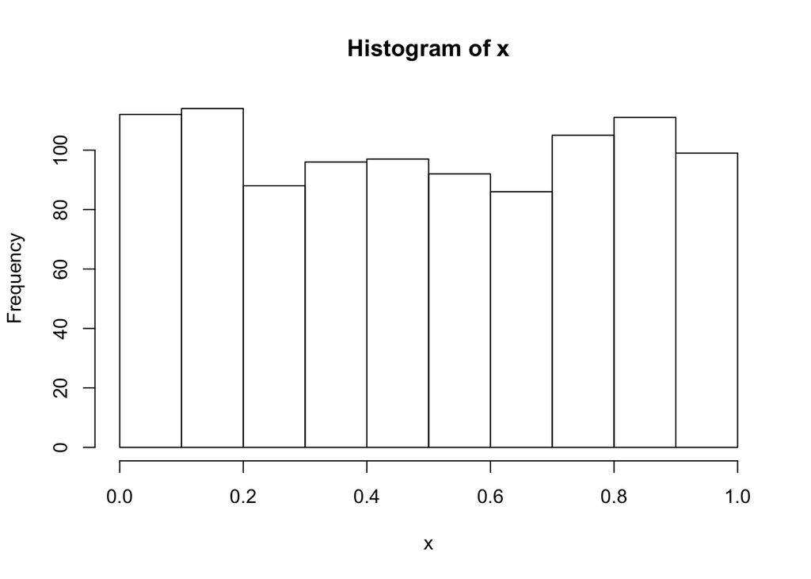

```r
x <- runif(1000)
hist(x)
```

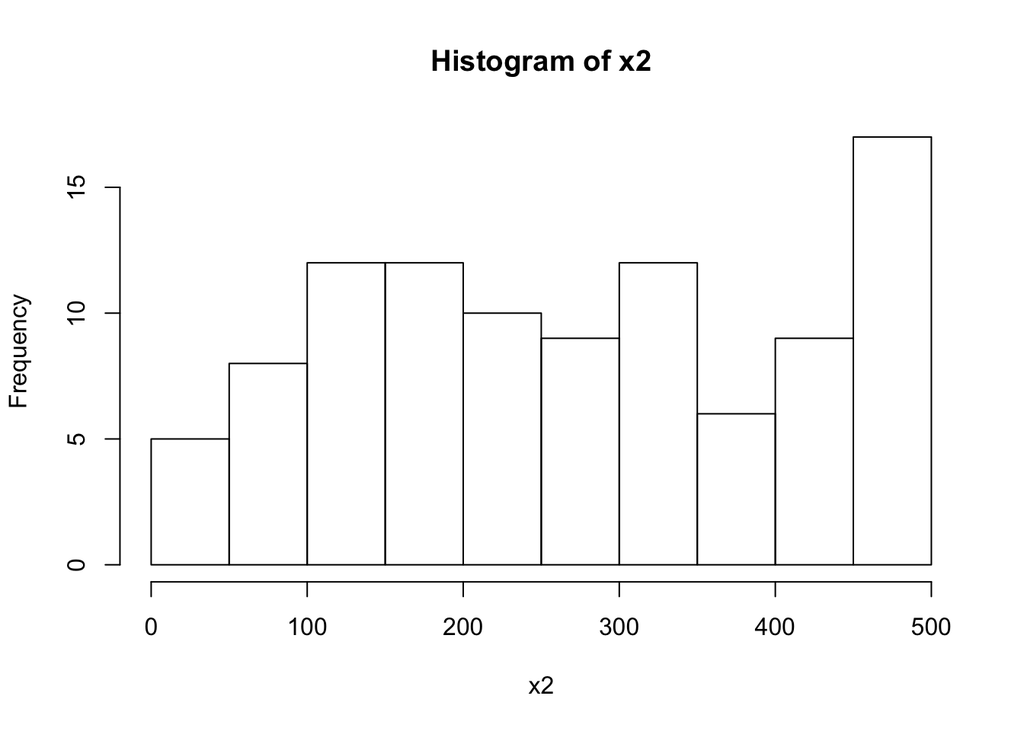

```r
x2 <- runif(100, min=0, max=500)
hist(x2)
```

```r
?rnorm
rnorm(10)
```

```
##  [1] -0.13372589  1.07806493 -0.48723645 -0.34604182  1.68121109
##  [6] -0.06256705 -1.20668142  1.60462497  1.31906405 -0.17077410
```

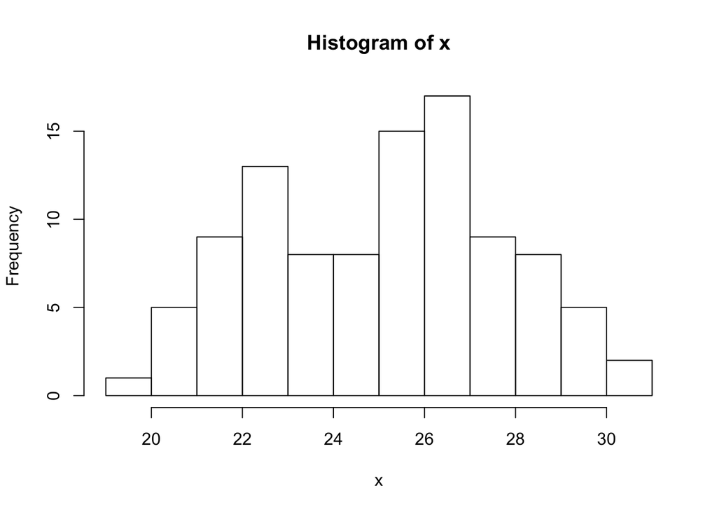

```r
x <- rnorm(100, mean=25, sd=2)
hist(x)
```

```r
?rpois
?rexp
?Distributions
```

# **The seed**

**VERY important** for randomized sampling proceedures The seed is a position in a numbers matrix that R uses to start its algorithms of randomized sampling functions. By setting the seed, we can control the generation of random numbers. This becomes important when e.g. wanting to replicate exactly a randomization experiment or when wanting to make sure that *different* random samples are drawn from a distribution.

```r
??set.seed

rnorm(100)
```

```
##   [1]  0.92660021  0.39448465  1.11443824  1.88563142  0.07169975
##   [6] -2.09243330 -2.05314070 -0.39000339 -0.28414251 -0.56125660
##  [11]  0.97159684 -1.81495956 -1.41778910 -1.60842244  1.48101111
##  [16] -2.05446688 -0.58616337 -0.23286268  1.10502885  1.55080827
##  [21]  0.24727073  0.25935733  0.28924173 -0.96778921 -1.74552405
##  [26] -0.79369258  1.62919767  2.73643017 -1.49668558  0.06665711
##  [31]  0.57607981 -0.34694992  1.23597837 -0.66732427  1.92093245
##  [36]  0.31180600  0.79131416  1.45047136 -0.94598555 -0.23150024
##  [41]  1.00163544  0.45936722 -0.08673584 -2.23473001  2.41921136
##  [46] -1.06545972  0.26564106 -0.01645662 -0.70937549  1.34526142
##  [51] -0.59795395 -0.47367647 -2.00032254 -0.04793881  0.08613584
##  [56]  0.41261420  1.75461339  1.11261834  0.89425137 -1.87514113
##  [61]  0.57825124  0.70442018 -0.25822115  2.51813124 -0.47255695
##  [66]  0.24805971  1.41490229 -0.69084842 -0.90624143  1.09775282
##  [71] -1.67204877  0.05095039  1.14420751  0.43851945 -0.18905119
##  [76]  0.37756668  0.27712869 -0.89497268  0.68424236  0.03838136
##  [81] -2.57718392  1.60316356 -0.10370708  2.26208100  0.11807593
##  [86] -0.22566304 -1.03850643 -0.32509131 -0.54400022 -0.45982707
##  [91]  0.64806562 -2.07655408 -0.00452383 -0.80589139 -0.97518841
##  [96]  0.13207558 -1.63476991  1.03328307 -1.43212193 -0.94380523
```

```r
rnorm(100)
```

```
##   [1]  0.58936422 -1.14014197 -0.54586476  0.38894257 -0.03327070
##   [6] -1.46016503 -0.11967513 -0.90534934  1.76891075  0.29634432
##  [11]  1.08794203 -0.84126179 -0.68922985  0.62192575 -0.49256617
##  [16]  0.04603547 -0.03834525 -0.67964702 -1.12971701  0.13547789
##  [21] -0.75292939 -0.25174452 -0.15613204  0.05172844  1.12128964
##  [26] -0.86890150  0.31532102  0.96888465  1.18419256  1.97680318
##  [31] -1.29641301  1.22408083 -0.43713119  0.21154289  2.38400325
##  [36] -0.24232483  1.05175472 -1.71674915  0.38612296 -1.50661056
##  [41]  1.10259326  1.02696766  1.11739462  1.02567979  0.20535514
##  [46]  0.22543307 -0.45773238  0.50597935 -0.11593064 -0.88311316
##  [51] -0.57333524  0.34260379  0.86969086 -0.45923092 -0.67852142
##  [56] -0.96324107  0.31247844 -0.63469101  1.49567196  1.15333163
##  [61]  0.68779847 -0.94740364  0.76683206  1.09257955  1.40820701
##  [66] -0.75135591 -1.24335146  1.30731701 -1.90553153  0.98904313
##  [71] -0.67083537  0.43940218  0.85160630 -0.29469357  0.04946575
##  [76]  0.22860911  0.29400441 -1.24165656 -0.49450419 -1.82607054
##  [81] -1.64298413  0.80817207 -0.38093244 -0.36753670  0.95752881
##  [86]  3.41493212 -0.29802381 -0.95267449  2.79519664 -0.30962550
##  [91]  0.07781626 -0.05182167  0.71489951 -0.13437177  1.51526198
##  [96]  1.10988604  2.44649457 -0.60683802  0.05803217 -0.05413368
```

```r
set.seed(123)
x <- rnorm(100)
x
```

```
##   [1] -0.560475647 -0.230177489  1.558708314  0.070508391  0.129287735
##   [6]  1.715064987  0.460916206 -1.265061235 -0.686852852 -0.445661970
##  [11]  1.224081797  0.359813827  0.400771451  0.110682716 -0.555841135
##  [16]  1.786913137  0.497850478 -1.966617157  0.701355902 -0.472791408
##  [21] -1.067823706 -0.217974915 -1.026004448 -0.728891229 -0.625039268
##  [26] -1.686693311  0.837787044  0.153373118 -1.138136937  1.253814921
##  [31]  0.426464221 -0.295071483  0.895125661  0.878133488  0.821581082
##  [36]  0.688640254  0.553917654 -0.061911711 -0.305962664 -0.380471001
##  [41] -0.694706979 -0.207917278 -1.265396352  2.168955965  1.207961998
##  [46] -1.123108583 -0.402884835 -0.466655354  0.779965118 -0.083369066
##  [51]  0.253318514 -0.028546755 -0.042870457  1.368602284 -0.225770986
##  [56]  1.516470604 -1.548752804  0.584613750  0.123854244  0.215941569
##  [61]  0.379639483 -0.502323453 -0.333207384 -1.018575383 -1.071791226
##  [66]  0.303528641  0.448209779  0.053004227  0.922267468  2.050084686
##  [71] -0.491031166 -2.309168876  1.005738524 -0.709200763 -0.688008616
##  [76]  1.025571370 -0.284773007 -1.220717712  0.181303480 -0.138891362
##  [81]  0.005764186  0.385280401 -0.370660032  0.644376549 -0.220486562
##  [86]  0.331781964  1.096839013  0.435181491 -0.325931586  1.148807618
##  [91]  0.993503856  0.548396960  0.238731735 -0.627906076  1.360652449
##  [96] -0.600259587  2.187332993  1.532610626 -0.235700359 -1.026420900
```

```r
set.seed(123)
y <- rnorm(100)
y
```

```
##   [1] -0.560475647 -0.230177489  1.558708314  0.070508391  0.129287735
##   [6]  1.715064987  0.460916206 -1.265061235 -0.686852852 -0.445661970
##  [11]  1.224081797  0.359813827  0.400771451  0.110682716 -0.555841135
##  [16]  1.786913137  0.497850478 -1.966617157  0.701355902 -0.472791408
##  [21] -1.067823706 -0.217974915 -1.026004448 -0.728891229 -0.625039268
##  [26] -1.686693311  0.837787044  0.153373118 -1.138136937  1.253814921
##  [31]  0.426464221 -0.295071483  0.895125661  0.878133488  0.821581082
##  [36]  0.688640254  0.553917654 -0.061911711 -0.305962664 -0.380471001
##  [41] -0.694706979 -0.207917278 -1.265396352  2.168955965  1.207961998
##  [46] -1.123108583 -0.402884835 -0.466655354  0.779965118 -0.083369066
##  [51]  0.253318514 -0.028546755 -0.042870457  1.368602284 -0.225770986
##  [56]  1.516470604 -1.548752804  0.584613750  0.123854244  0.215941569
##  [61]  0.379639483 -0.502323453 -0.333207384 -1.018575383 -1.071791226
##  [66]  0.303528641  0.448209779  0.053004227  0.922267468  2.050084686
##  [71] -0.491031166 -2.309168876  1.005738524 -0.709200763 -0.688008616
##  [76]  1.025571370 -0.284773007 -1.220717712  0.181303480 -0.138891362
##  [81]  0.005764186  0.385280401 -0.370660032  0.644376549 -0.220486562
##  [86]  0.331781964  1.096839013  0.435181491 -0.325931586  1.148807618
##  [91]  0.993503856  0.548396960  0.238731735 -0.627906076  1.360652449
##  [96] -0.600259587  2.187332993  1.532610626 -0.235700359 -1.026420900
```

# **Naming vectors**

The elements of a vector can be named. This is useful for data organization and inndexing.

```r
size1 <- c(20, 50, 100, 25 , 5, 20)
size1
```

```
## [1]  20  50 100  25   5  20
```

```r
country <- c("Portugal", "Spain", "France", "Italy", "Denmark", "Finland")

names(size1) <- country
size1
```

```
## Portugal    Spain   France    Italy  Denmark  Finland
##       20       50      100       25        5       20
```

## **OPERATIONS WITH VECTORS**

Operations with vectors are conducted elementwise.

```r
a <- c(10, 30, 50, 70, 25)
5 + a
```

```
## [1] 15 35 55 75 30
```

```r
5 * a
```

```
## [1]  50 150 250 350 125
```

```r
a / 5
```

```
## [1]  2  6 10 14  5
```

```r
b <- seq(5, 25, by=5)
c <- a + b
a
```

```
## [1] 10 30 50 70 25
```

```r
b
```

```
## [1]  5 10 15 20 25
```

```r
c
```

```
## [1] 15 40 65 90 50
```

# **Recycling**

When two vectors are of unequal length, the shorter one will be recycled in order to match the longer vector

```r
d <- c(20, 5)
a - d
```

```
## [1] -10  25  30  65   5
```

```r
a * d
```

```
## Warning in a * d: longer object length is not a multiple of shorter object
## length
```

```
## [1]  200  150 1000  350  500
```

**VERY IMPORTANT:** READ WARNINGS AND ERRORS!!! But be careful, because the warning is **only** shown if the vectors are *fractionally* recycled:

```r
length(a)
```

```
## [1] 5
```

```r
length(d)
```

```
## [1] 2
```

```r
rep(a, 2) - d
```

```
##  [1] -10  25  30  65   5   5  10  45  50  20
```

# **Comparing vectors**

R uses specific symbology that allows us to compare vectors, again in an elemntwise manner.

```r
size1 <- c(20, 50, 100, 25, 5, 20)
size2 <- c(12, 15, 10, 5, 5, 15)

size1 == size2
```

```
## [1] FALSE FALSE FALSE FALSE  TRUE FALSE
```

```r
size1 > size2
```

```
## [1]  TRUE  TRUE  TRUE  TRUE FALSE  TRUE
```

```r
size2 <= size1
```

```
## [1] TRUE TRUE TRUE TRUE TRUE TRUE
```

```r
size1%in%size2
```

```
## [1] FALSE FALSE FALSE FALSE  TRUE FALSE
```

```r
any(size1 > size2)
```

```
## [1] TRUE
```

```r
all(size1 > size2)
```

```
## [1] FALSE
```

## **VECTOR POSITIONS**

Remember: a vector is an object with one dimension. Elements of the vector can be retrieved based on their (uni-dimensional) position in the vector using straight brackets.

```r
size1[1]
```

```
## [1] 20
```

```r
size2[5]
```

```
## [1] 5
```

```r
size2[-1]
```

```
## [1] 15 10  5  5 15
```

More on this tommorow, when we discuss indexing.

## **MATRICES**

A matrix is a two-dimensional array (two dimmensions) of values A matrix is a collection of vectors (e.g. measurements of several variables for the same objects) A matrix can only contain data of the same type, as is the case for vectors

Let’s define three vectors: V1 containing numbers form 1 to 5 V2 containing numbers form 100 to 108 with a step of 2 V3 containing the number 50 five times

```r
V1 <- c(1:5)
V2 <- seq(100, 108, 2)
V3 <- rep(50, 5)
```

# **Creating matrices**

Two major functions for creating matrices are cbind() and rbind(), which allow us to bind together vectors (or matrices) by columns or by rows.

```r
cbind(V1, V2, V3)
```

```
##      V1  V2 V3
## [1,]  1 100 50
## [2,]  2 102 50
## [3,]  3 104 50
## [4,]  4 106 50
## [5,]  5 108 50
```

```r
rbind(V1, V2, V3)
```

```
##    [,1] [,2] [,3] [,4] [,5]
## V1    1    2    3    4    5
## V2  100  102  104  106  108
## V3   50   50   50   50   50
```

This works because the three vectors have the same length, but if that were not the case R would apply *recycling* to bind the vectors.

```r
V4 <- 10:16
rbind(V1, V4)
```

```
## Warning in rbind(V1, V4): number of columns of result is not a multiple of
## vector length (arg 1)
```

```
##    [,1] [,2] [,3] [,4] [,5] [,6] [,7]
## V1    1    2    3    4    5    1    2
## V4   10   11   12   13   14   15   16
```

Again, be careful, because the warning is shown only if the vectors are *fractionally* recycled:

```r
V5 <- 1:3
V6 <- 1:6
rbind(V5,V6)
```

```
##    [,1] [,2] [,3] [,4] [,5] [,6]
## V5    1    2    3    1    2    3
## V6    1    2    3    4    5    6
```

Most usually, matrices are created using the **matrix()** function:

```r
matrix(nrow=3, ncol=5)
```

```
##      [,1] [,2] [,3] [,4] [,5]
## [1,]   NA   NA   NA   NA   NA
## [2,]   NA   NA   NA   NA   NA
## [3,]   NA   NA   NA   NA   NA
```

```r
matrix(0, nrow=3, ncol=5)
```

```
##      [,1] [,2] [,3] [,4] [,5]
## [1,]    0    0    0    0    0
## [2,]    0    0    0    0    0
## [3,]    0    0    0    0    0
```

```r
matrix(1:15, nrow=3, ncol=5)
```

```
##      [,1] [,2] [,3] [,4] [,5]
## [1,]    1    4    7   10   13
## [2,]    2    5    8   11   14
## [3,]    3    6    9   12   15
```

```r
matrix(c(1:15), nrow=3)
```

```
##      [,1] [,2] [,3] [,4] [,5]
## [1,]    1    4    7   10   13
## [2,]    2    5    8   11   14
## [3,]    3    6    9   12   15
```

But *careful*, to define a matrix, you need to define its dimensions! If not, a one-column matrix is assumed (which is not the same as a vector).

```r
poo <- matrix(c(1:15))
poo
```

```
##       [,1]
##  [1,]    1
##  [2,]    2
##  [3,]    3
##  [4,]    4
##  [5,]    5
##  [6,]    6
##  [7,]    7
##  [8,]    8
##  [9,]    9
## [10,]   10
## [11,]   11
## [12,]   12
## [13,]   13
## [14,]   14
## [15,]   15
```

```r
c(1:15)
```

```
##  [1]  1  2  3  4  5  6  7  8  9 10 11 12 13 14 15
```

The argument *byrow* allows us to control in which direction the matrix will be filled.

```r
matrix(1:15, nrow=3, ncol=5, byrow=TRUE)
```

```
##      [,1] [,2] [,3] [,4] [,5]
## [1,]    1    2    3    4    5
## [2,]    6    7    8    9   10
## [3,]   11   12   13   14   15
```

Again, careful with matrix dimensions and treaming or recycling warning messages.

```r
matrix(1:17, nrow=3, ncol=5)
```

```
## Warning in matrix(1:17, nrow = 3, ncol = 5): data length [17] is not a sub-
## multiple or multiple of the number of rows [3]
```

```
##      [,1] [,2] [,3] [,4] [,5]
## [1,]    1    4    7   10   13
## [2,]    2    5    8   11   14
## [3,]    3    6    9   12   15
```

```r
matrix(1:17, nrow=3)
```

```
##      [,1] [,2] [,3] [,4] [,5] [,6]
## [1,]    1    4    7   10   13   16
## [2,]    2    5    8   11   14   17
## [3,]    3    6    9   12   15    1
```

## **Naming matrices**

Same as for vectors, the positions of matrices can be named, in this case through row and column names.

```r
mat1 <- rbind(V1,V2,V3)
mat2 <- cbind(V1,V2,V3)

mat1
```

```
##    [,1] [,2] [,3] [,4] [,5]
## V1    1    2    3    4    5
## V2  100  102  104  106  108
## V3   50   50   50   50   50
```

```r
mat2
```

```
##      V1  V2 V3
## [1,]  1 100 50
## [2,]  2 102 50
## [3,]  3 104 50
## [4,]  4 106 50
## [5,]  5 108 50
```

```r
rownames(mat1)
```

```
## [1] "V1" "V2" "V3"
```

```r
rownames(mat2)
```

[output not shown]

```r
colnames(mat2)
```

```
## [1] "V1" "V2" "V3"
```

```r
dimnames(mat1)
```

```
## [[1]]
## [1] "V1" "V2" "V3"
##
## [[2]]
## NULL
```

```r
rownames(mat2) <- country[-6]
dimnames(mat2)
```

```
## [[1]]
## [1] "Portugal" "Spain"    "France"   "Italy"    "Denmark"
##
## [[2]]
## [1] "V1" "V2" "V3"
```

```r
mat2
```

```
##          V1  V2 V3
## Portugal  1 100 50
## Spain     2 102 50
## France    3 104 50
## Italy     4 106 50
## Denmark   5 108 50
```

## **EXERCISE:**

```r
my.exp <- matrix(sample(1:1000,20), nrow=5, ncol=4)
rownames(my.exp) <- paste("Treatment", 1:5, sep="")
colnames(my.exp) <- paste("Gene", 1:4, sep="")
```

# **Matrix positions**

Matrices have two dimensions: rows and columns. As such, their positions are defined based on the coordinates for these two dimensions

```r
dim(mat2)
```

```
## [1] 5 3
```

```r
mat2
```

```
##          V1  V2 V3
## Portugal  1 100 50
## Spain     2 102 50
## France    3 104 50
## Italy     4 106 50
## Denmark   5 108 50
```

```r
mat2[3, 2]
```

```
## [1] 104
```

```r
mat2["France", "V2"]
```

```
## [1] 104
```

# **Operations with matrices**

Also work elementwise

```r
mat1
```

```
##    [,1] [,2] [,3] [,4] [,5]
## V1    1    2    3    4    5
## V2  100  102  104  106  108
## V3   50   50   50   50   50
```

```r
mat1 + 4
```

```
##    [,1] [,2] [,3] [,4] [,5]
## V1    5    6    7    8    9
## V2  104  106  108  110  112
## V3   54   54   54   54   54
```

```r
mat1 * 10
```

```
##    [,1] [,2] [,3] [,4] [,5]
## V1   10   20   30   40   50
## V2 1000 1020 1040 1060 1080
## V3  500  500  500  500  500
```

```r
# mat1 + mat2 doesn´t work because matrices do not have the same dimensions
```

Matrices can also be transposed:

```r
t(mat2)
```

```
##    Portugal Spain France Italy Denmark
## V1        1     2      3     4       5
## V2      100   102    104   106     108
## V3       50    50     50    50      50
```

```r
mat1 + t(mat2)
```

```
##    [,1] [,2] [,3] [,4] [,5]
## V1    2    4    6    8   10
## V2  200  204  208  212  216
## V3  100  100  100  100  100
```

One can also perform summary operations **by rows or by columns** of a matrix:

```r
colSums(mat1)
```

```
## [1] 151 154 157 160 163
```

```r
rowSums(mat1)
```

```
##  V1  V2  V3
##  15 520 250
```

```r
colMeans(mat1)
```

```
## [1] 50.33333 51.33333 52.33333 53.33333 54.33333
```

```r
rowMeans(mat1)
```

```
##  V1  V2  V3
##   3 104  50
```

A more general function that allows us to do this - and many many other things - is **apply()**. Apply uses the *margin* argument to define if operations are done by rows (margin = 1) or by columns (margin = 2)

```r
apply(mat1, 1, sum)
```

```
##  V1  V2  V3
##  15 520 250
```

```r
apply(mat1, 2, sum)
```

```
## [1] 151 154 157 160 163
```

Using **apply()** one can apply (pun intended) any function by rows or columns

```r
apply(mat1, 1, max)
```

```
##  V1  V2  V3
##   5 108  50
```

```r
apply(mat1, 2, mean)
```

```
## [1] 50.33333 51.33333 52.33333 53.33333 54.33333
```

**NOTE:** apply() is member of a family of functions that also includes: - tapply() for applying a function to an array by a grouping factor - lapply() and sapply() for applying a function to parts of a list (see next lecture) All these functions are EXTREMELY useful when an operation needs to be repeated across elements of a matrix, array or list. Their use and behaviour is a bit complex to cover in this course, but keep them in mind whenever you are trying to apply a function to specific margins of your data.

## **ARRAYS**

An array is a three-dimensional object (three dimmension) of numbers or characters An array is a collection of matrices (e.g. measurements of several variables for the same objects, across treatments) An array can only contain data of the same type

```r
ARR <- array(1:12, dim=c(2,3,2))
ARR
```

```
## , , 1
##
##      [,1] [,2] [,3]
## [1,]    1    3    5
## [2,]    2    4    6
##
## , , 2
##
##      [,1] [,2] [,3]
## [1,]    7    9   11
## [2,]    8   10   12
```

```r
dim(V1)
```

[output not shown]

```r
dim(mat1)
```

```
## [1] 3 5
```

```r
dim(ARR)
```

```
## [1] 2 3 2
```

```r
my.exp1 <- my.exp
my.exp2 <- matrix(sample(1:1000, 20), nrow=5, ncol=4)
my.exp3 <- matrix(sample(1:1000, 20), nrow=5, ncol=4)

my.array <- array(c(my.exp1,my.exp2,my.exp3), dim=c(5,4,3))
dimnames(my.array) <- list(paste("Treatment",1:5), paste("Gene",1:4), paste("Time",0:2))

my.array
```

```
## , , Time 0
##
##             Gene 1 Gene 2 Gene 3 Gene 4
## Treatment 1    239    876    478    691
## Treatment 2    962    362    251    347
## Treatment 3    601    287    214    402
## Treatment 4    514    170    666    807
## Treatment 5    401    171     47    902
##
## , , Time 1
##
##             Gene 1 Gene 2 Gene 3 Gene 4
## Treatment 1    283    394    613    392
## Treatment 2    961    475    424    195
## Treatment 3    727    557    536    818
## Treatment 4    685    693     58    151
## Treatment 5     53    908    258    789
##
## , , Time 2
##
##             Gene 1 Gene 2 Gene 3 Gene 4
## Treatment 1    547    721    255    774
## Treatment 2    662    397    220    166
## Treatment 3    172    963    586    398
## Treatment 4    632    960    265    464
## Treatment 5    311    995    524    852
```

```r
str(my.array)
```

```
##  int [1:5, 1:4, 1:3] 239 962 601 514 401 876 362 287 170 171 ...
##  - attr(*, "dimnames")=List of 3
##   ..$ : chr [1:5] "Treatment 1" "Treatment 2" "Treatment 3" "Treatment 4" ...
##   ..$ : chr [1:4] "Gene 1" "Gene 2" "Gene 3" "Gene 4"
##   ..$ : chr [1:3] "Time 0" "Time 1" "Time 2"
```

```r
dimnames(my.array)
```

```
## [[1]]
## [1] "Treatment 1" "Treatment 2" "Treatment 3" "Treatment 4" "Treatment 5"
##
## [[2]]
## [1] "Gene 1" "Gene 2" "Gene 3" "Gene 4"
##
## [[3]]
## [1] "Time 0" "Time 1" "Time 2"
```

**apply()** also works for any of the margins of an array:

```r
apply(my.array, 2, mean)
```

```
##   Gene 1   Gene 2   Gene 3   Gene 4
## 516.6667 595.2667 359.6667 543.2000
```

```r
apply(my.array, 3, mean)
```

```
## Time 0 Time 1 Time 2
##  469.4  498.5  543.2
```

```r
apply(my.array, 1, mean)
```

```
## Treatment 1 Treatment 2 Treatment 3 Treatment 4 Treatment 5
##    521.9167    451.8333    521.7500    505.4167    517.5833
```

We can also ask for a function to be applied on *TWO* margins of an array. In this case, the function returns a matrix, rather than a vector, of values.

```r
apply(my.array, 1:2, mean)
```

```
##               Gene 1   Gene 2   Gene 3   Gene 4
## Treatment 1 356.3333 663.6667 448.6667 619.0000
## Treatment 2 861.6667 411.3333 298.3333 236.0000
## Treatment 3 500.0000 602.3333 445.3333 539.3333
## Treatment 4 610.3333 607.6667 329.6667 474.0000
## Treatment 5 255.0000 691.3333 276.3333 847.6667
```